# Управление логическими томами

Майоров Дмитрий Андреевич

# Информация

## Докладчик

- Майоров Дмитрий Андреевич

# Цель работы

Получить навыки управления логическими томами

# Выполнение лабораторной работы

Получаем полномочия администратора. Открываем файл /etc/fstab для редактирования. Удаляем строку автомонтирования /mnt/data

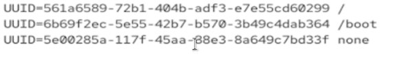

Рисунок 1

# Выполнение лабораторной работы

Отмонтируем /mnt/data и /mnt/data-ext

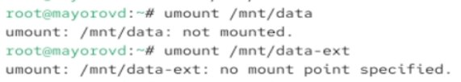

Рисунок 2

# Выполнение лабораторной работы

Создаем новый виртуальный жесткий диск. Будем работать с ним

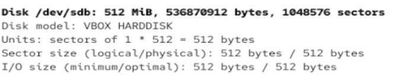

Рисунок 3

# Выполнение лабораторной работы

Создаем основной раздел с типом LVM

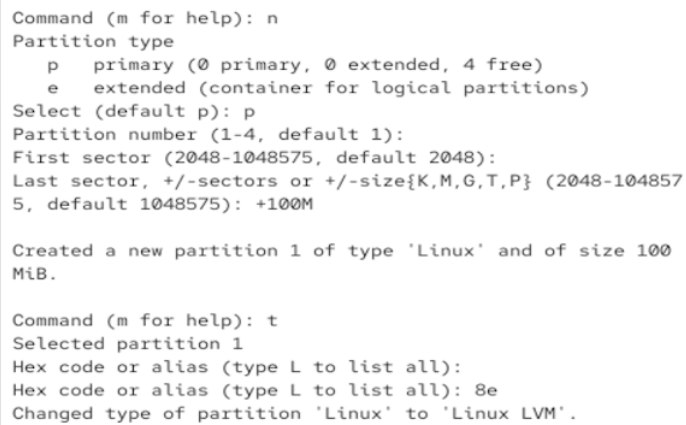

Рисунок 4

# Выполнение лабораторной работы

Обновляем таблицу разделов. Указываем раздел, как физическим том LVM. Вводим pvs, чтобы убедиться, что физический том создан успешно

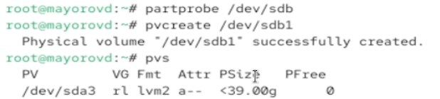

Рисунок 5

# Выполнение лабораторной работы

Проверяем доступность физических томов в системе

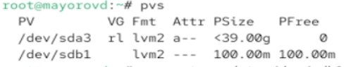

Рисунок 6

# Выполнение лабораторной работы

СОздаем группу томов с присвоенным ей физическим томом. Убеждаемся, что группа томов была создана успешно

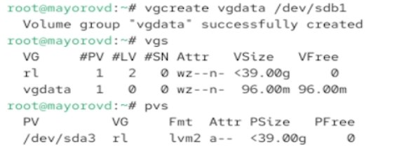

Рисунок 7

# Выполнение лабораторной работы

Создаем логический том LVM с именем lvdata. Проверяем успешность добавления тома

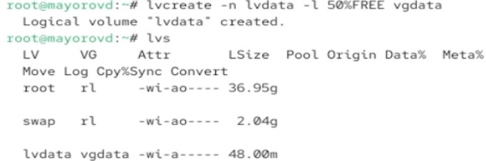

Рисунок 8

# Выполнение лабораторной работы

Создаем файловую систему поверх логического тома. Далее создаем папку, на которую можно смонтировать том

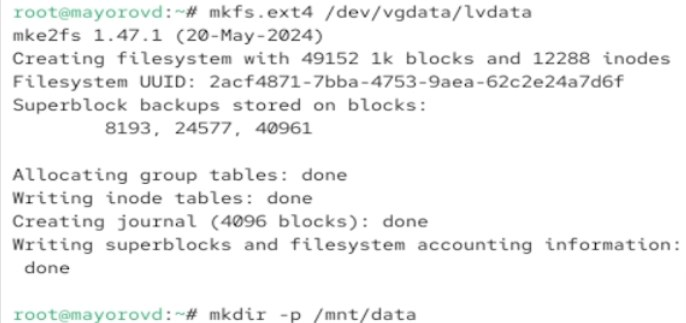

Рисунок 9

# Выполнение лабораторной работы

Добавляем следующую строку в /etc/fstab

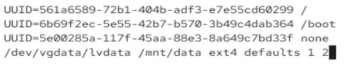

Рисунок 10

# Выполнение лабораторной работы

Проверяем, монтируется ли файловая система

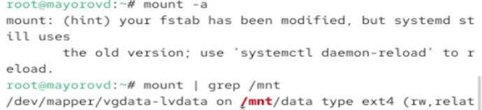

Рисунок 11

# Выполнение лабораторной работы

Отображаем текущую конфигурацию физических томов и группы томов

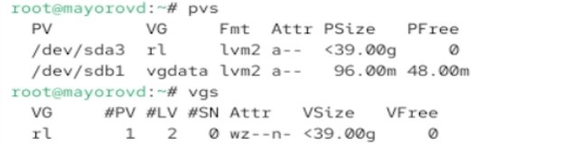

Рисунок 12

# Выполнение лабораторной работы

С помощью fdisk добавляем раздел /dev/sdb2 размером 100 М. Задаем тип раздела 8e

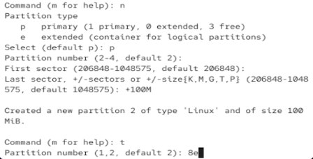

Рисунок 13

# Выполнение лабораторной работы

Создаем физический том. Расширяем vgdata. Проверяем, что размер доступной группы томов увеличен

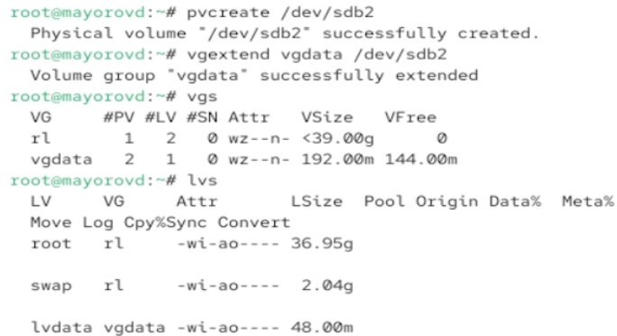

Рисунок 14

# Выполнение лабораторной работы

Проверяем текущий размер логического тома lvdata

[figure not shown]

Рисунок 15

# Выполнение лабораторной работы

Увеличиваем lvdata на 50% оставшегося доступного дискового пространства в группе томов

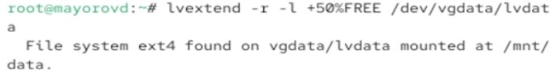

Рисунок 16

# Выполнение лабораторной работы

Убеждаемся, что добавленное дисковое пространство стало доступным

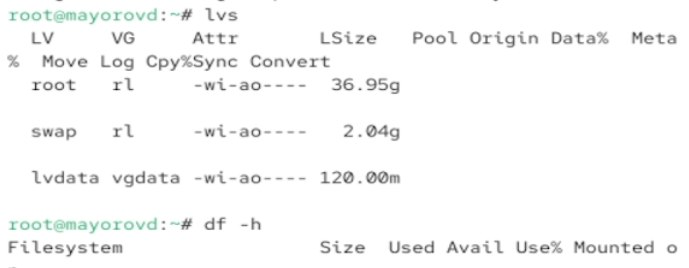

Рисунок 17

# Выполнение лабораторной работы

Уменьшаем размер lvdata на 50 МБ

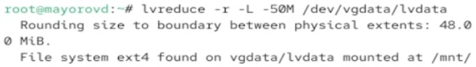

Рисунок 18

# Выполнение лабораторной работы

Убеждаемся в успешном изменении дискового пространства

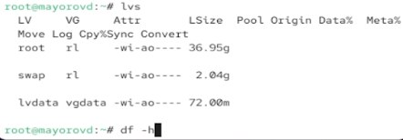

Рисунок 19

# Выводы

Получены навыки управления логическими томами